# Tema6-5(Graficos)

Pep Matemales

29/3/2020

# Diagrama de barras

## Un unico vector

```r
Respuestas=factor(sample(c("Si", "No"), size = 12, replace = TRUE))
Respuestas
```

```
##  [1] No No No Si No No Si Si Si No No No
## Levels: No Si
```

```r
Sexo= sample(c("H", "M"), size = length(Respuestas), replace = T) #H = hombre, M = mujer
Sexo
```

```
##  [1] "H" "M" "H" "H" "H" "H" "H" "H" "H" "M" "H" "M"
```

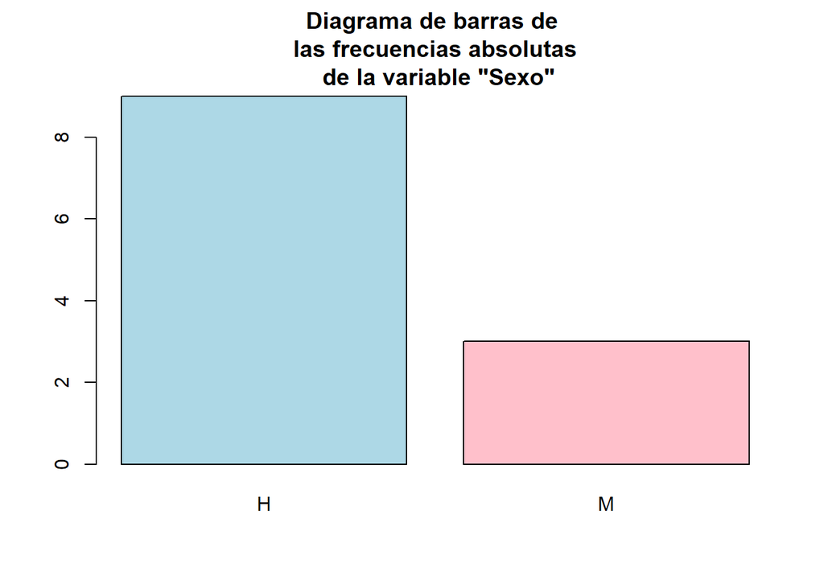

```r
barplot(table(Sexo), col=c("lightblue","pink"), main="Diagrama de barras de
las frecuencias absolutas\n de la variable \"Sexo\"")
```

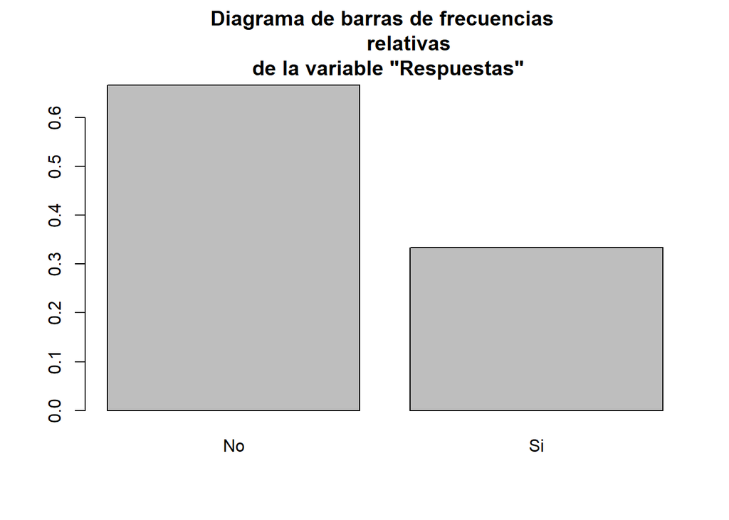

```r
barplot(prop.table(table(Respuestas)), main="Diagrama de barras de frecuencias
        relativas\n de la variable \"Respuestas\"")
```

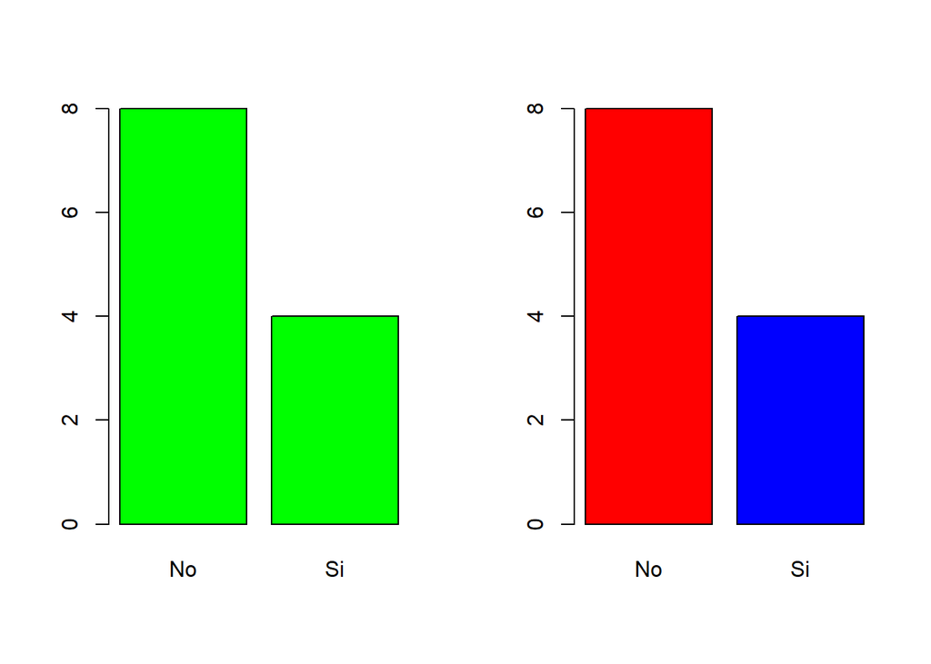

```r
par(mfrow=c(1,2))
barplot(table(Respuestas), col=c("green"))
barplot(table(Respuestas), col=c("red","blue"))
```

```r
par(mfrow = c(1,1))
```

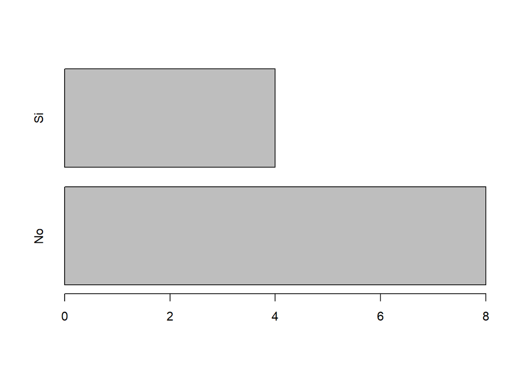

```r
barplot(table(Respuestas), horiz=TRUE)
```

## De tablas bidimensionales

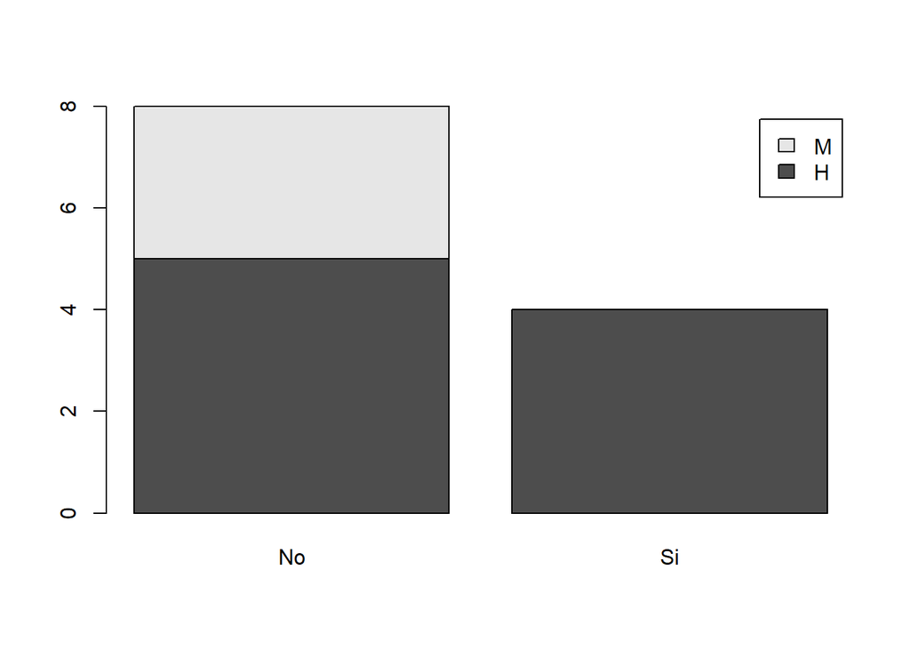

```r
barplot(table(Sexo,Respuestas), legend.text = TRUE)
```

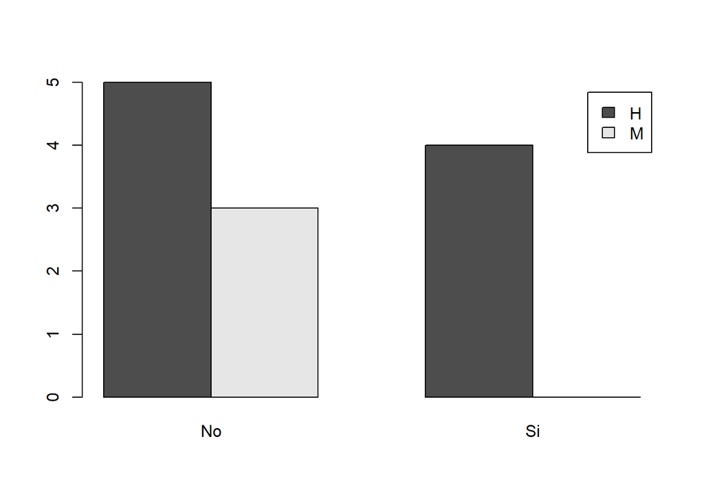

```r
barplot(table(Sexo,Respuestas), beside=TRUE, legend.text=TRUE)
```

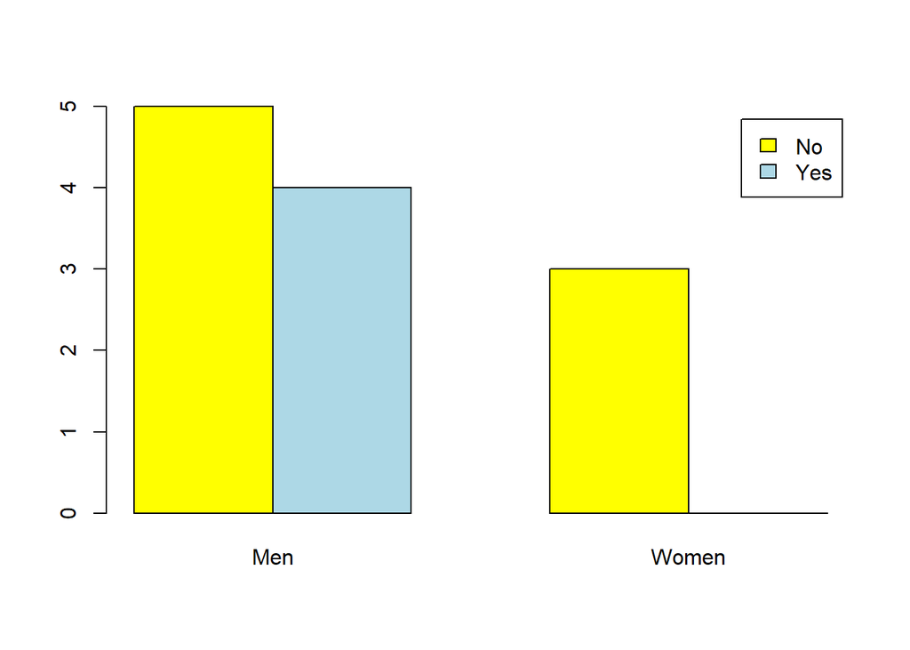

```r
barplot(table(Respuestas,Sexo), beside=TRUE, names=c("Men", "Women"),
        col=c("yellow","lightblue"), legend.text=c("No","Yes"))
```

# Diagrama circular (pie chart)

```r
x = sample(1:5, size = 12, replace = TRUE)
x
```

```
##  [1] 5 1 3 3 4 3 3 4 5 3 1 1
```

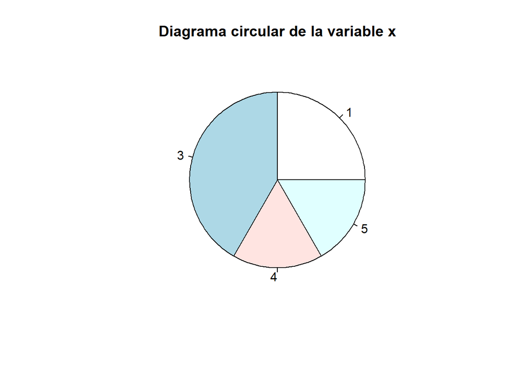

```r
pie(table(x), main="Diagrama circular de la variable x")
```

```r
Respuestas
```

```
##  [1] No No No Si No No Si Si Si No No No
## Levels: No Si
```

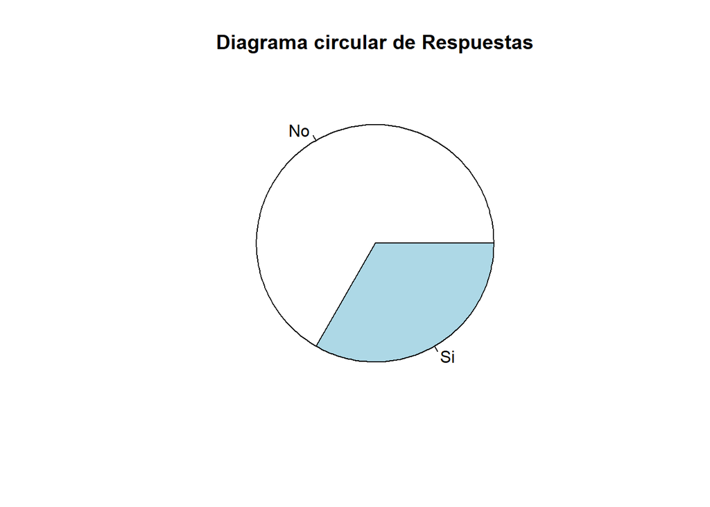

```r
pie(table(Respuestas), main="Diagrama circular de Respuestas")
```

# Diagrama de mosaico

## Bidimensional

En concreto, para obtener el gráfico de mosaico de una tabla bidimensional, se parte de un cuadrado de lado 1, primero se divide en barras verticales de amplitudes iguales a las frecuencias relativas de una variable, y luego cada barra se divide, a lo alto, en regiones de alturas proporcionales a las frecuencias relativas marginales de cada nivel de la otra variable, dentro del nivel correspondiente de la primera variable.

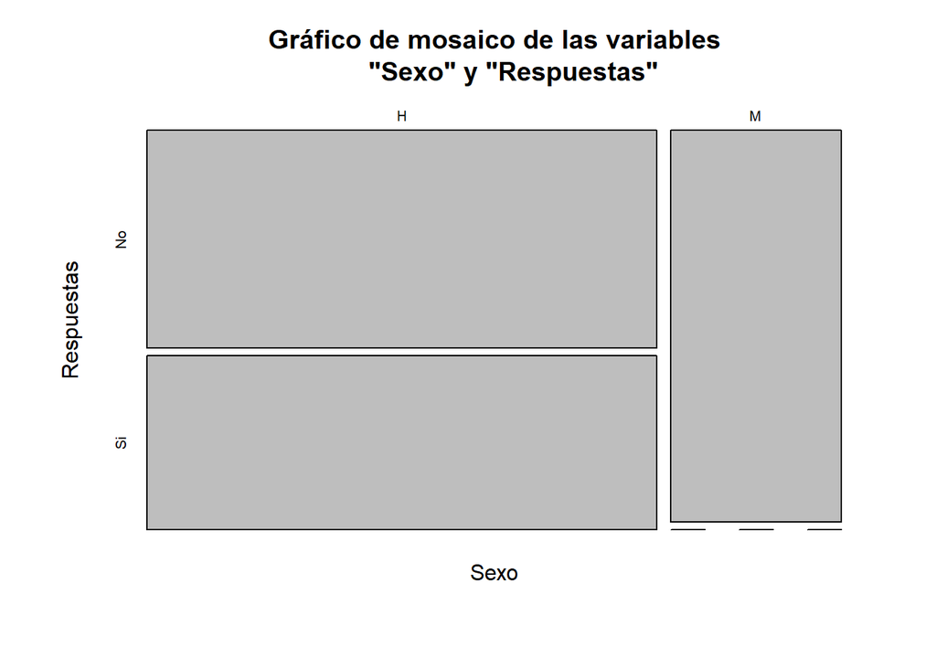

```r
plot(table(Sexo,Respuestas), main="Gráfico de mosaico de las variables
     \"Sexo\" y \"Respuestas\"")
```